# 수리통계학 Ⅱ - chap 6 실습

이하늘, 가천대학교 응용통계학과 202340339

2023-04-15(SAT)

# 1. 타이핑 오타의 수 평균 $\theta$인 포아송 분포를 따른다고 한다. 무정보 사전분포 제프리 사전분포를 가정하기로 하였다. 처음 6페이지를 보니 오타수가 3,2,4,3,2,1이었다. 주어진 정보를 가지고 승진이의 평균 페이지 당 오타수인 $\theta$의 사후분포를 유도하고 R로 사후분포의 밀도함수를 그려보아라.

$$n = 6, \displaystyle\sum_ x_i, \overline{x_1} = 2.5$$

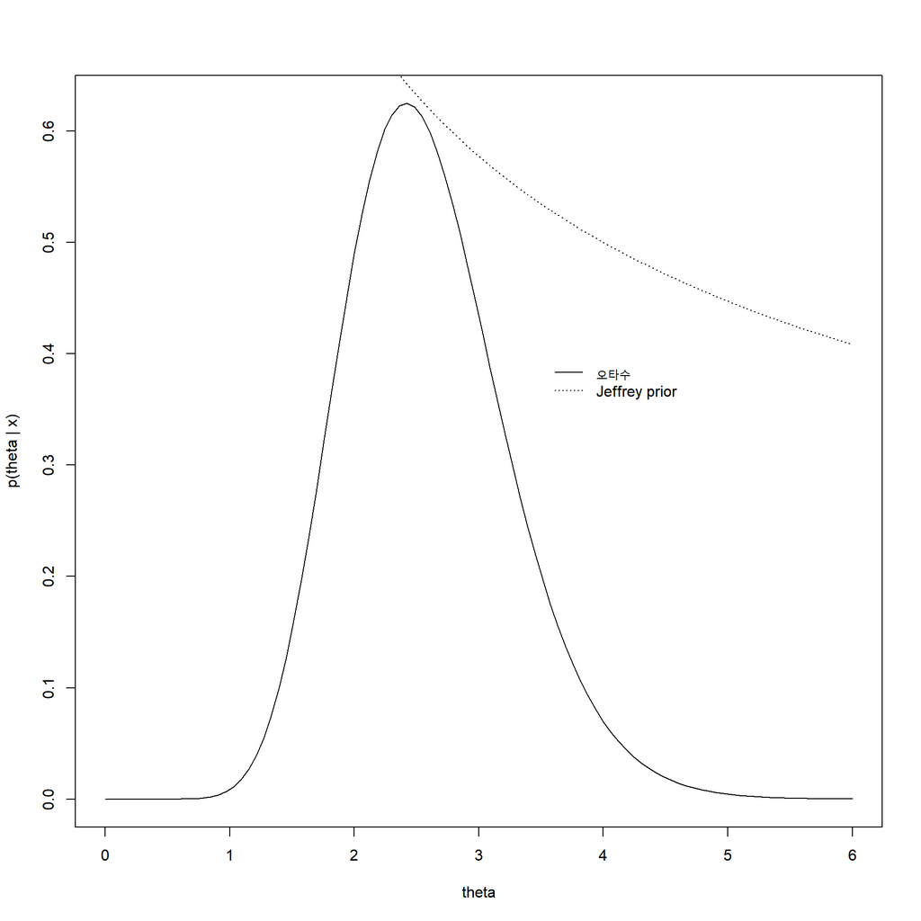

```r
a = 1/2; b = 0
x <- c(3,2,4,3,2,1)
n = length(x); s = sum(x)

postmean.theta = (a+s)/(b+n)

theta=seq(0,6,length=100)

plot(theta, dgamma(theta, a+s, b+n), type="l", xlab="theta",ylab="p(theta | x)")
lines(theta, 1/sqrt(theta), lty=3)

legend(3.5, 0.4, legend=c(paste("오타수")
                          , paste("Jeffrey prior")),
       lty=c(1, 3), bty="n")
```

# 2. 보험사 상품의 수 X는 평균 $\theta$인 포아송 분포, 사전분포 Gamma(1,1) 가정

## 2-(1). 이번 달 영업사원이 12개 보험 상품 판매, $\theta$의 사후분포를 구하라. $\theta$의 사전평균과 사후평균의 차이를 비교해 보아라.

$$\mu = \frac{\alpha}{\beta} \\
사후분포\\
\pi(\theta|x_1,\cdots,x_n)\sim Gamma(\alpha+x, \beta + 1) \\
\alpha=1, \beta=1 \\
\pi(\theta|x_1,\cdots,x_n)\sim Gamma(1+12 =13, 1+1 = 2)$$

```r
# install necessary packages
library(ggplot2)
library(tidyverse)
# prior parameters
alpha_prior <- 1
beta_prior <- 1

# observed data
x <- 12

# posterior parameters
alpha_posterior <- alpha_prior + x
beta_posterior <- beta_prior + 1

# prior and posterior means of theta
prior_mean_theta <- alpha_prior / beta_prior
posterior_mean_theta <- alpha_posterior / beta_posterior

print(paste("Prior mean of theta: ", prior_mean_theta))
```

```
## [1] "Prior mean of theta:  1"
```

```r
print(paste("Posterior mean of theta: ", posterior_mean_theta))
```

```
## [1] "Posterior mean of theta:  6.5"
```

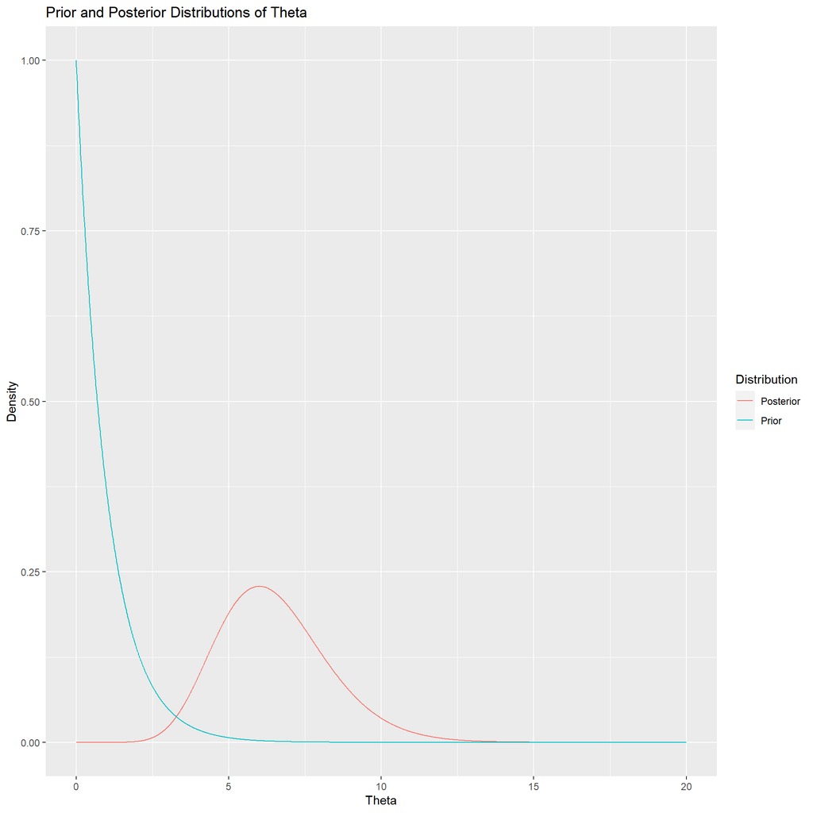

```r
# plot the density of the samples for the posterior distribution of theta
theta_values <- seq(from = 0 , to =20 , by =0.01)
prior_density <- dgamma(theta_values , shape = alpha_prior , rate = beta_prior)
posterior_density <- dgamma(theta_values , shape = alpha_posterior , rate = beta_posterior)

df <- data.frame(theta_values, prior_density, posterior_density)
colnames(df) <- c("Theta", "Prior", "Posterior")


df_long <- gather(df, Distribution, Density, -Theta)

ggplot(df_long, aes(x=Theta, y=Density)) +
  geom_line(aes(color=Distribution)) +
  labs(title="Prior and Posterior Distributions of Theta")
```

$$\theta 의 사전평균 => \mu = \frac{\alpha}{\beta} = \frac{1}{1} = 1
\\
\theta 의 사후평균 => \mu = \frac{13}{2} = 6.5$$

## 2-(2). 새로 고용된 신입 영업사원이 첫 달에 8개의 보험 상품을 팔았다고 했을 때 이 신입사원이 다음 달에 7~9개의 보험 상품을 팔게 될 확률을 구하라.

$$사후분포\\
\pi(\theta|x_1,\cdots,x_n)\sim Gamma(\alpha+x, \beta + 1) \\
\alpha=1, \beta=1 \\
\pi(\theta|x_1,\cdots,x_n)\sim Gamma(1+8 =9, 1+1 = 2) \\
X|θ \sim Poisson(θ) \\$$

$$다음 달에 7\sim9개의 보험 상품을 팔게 될 확률 \\
P(Y=7 or Y=8 or Y=9 | X=8) \\
P(Y=k | θ) (k=7, 8, 9) \\
P(Y < 9) - P(Y < 7)$$

```r
theta <- rgamma(n = 10000, shape = 9 , rate = 2)
prob <- mean(dpois(x = c(7:9), lambda = theta))
print(prob) #[1] 0.05334251
```

```
## [1] 0.05352487
```

```r
pgamma(9,9,2)-pgamma(7,9,2) #[1] 0.05499919
```

```
## [1] 0.05499919
```

# 3. 하루 동안 방문하는 네덜란드인의 수 X는 평균 $\theta$인 포아송 분포, 사전분포 Gamma(2,1) 가정, 4월 1일부터 10일까지 열흘 동안 관측한 결과 총 12명의 네덜란드인이 백화점을 방문

## 3-(1). $\theta$의 사후분포 구하고, R로 사후분포의 밀도함수 그리기

$$\mu = \frac{\alpha}{\beta} \\
사후분포\\
\pi(\theta|x_1,\cdots,x_n)\sim Gamma(\alpha+x, \beta + 10) \\
\alpha=2, \beta=1 \\
\pi(\theta|x_1,\cdots,x_n)\sim Gamma(2+12 =14, 1+10 = 11)$$

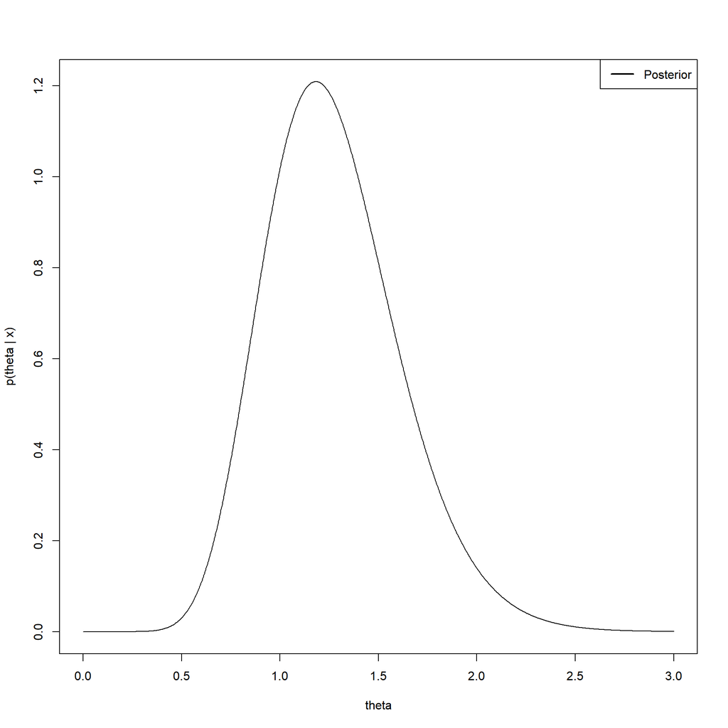

```r
# R 코드
a = 2; b=1
s = 12; n = 10
theta <- seq(0, 3, length.out = 1000)
plot(theta, dgamma(theta, a+s, b+n), type="l", xlab="theta",ylab="p(theta | x)")
legend("topright","Posterior",lty=1,lwd=2)
```

## 3-(2). $\theta$의 95% 사후구간(HPD)를 구하고 위 그림 위에 표시하라.

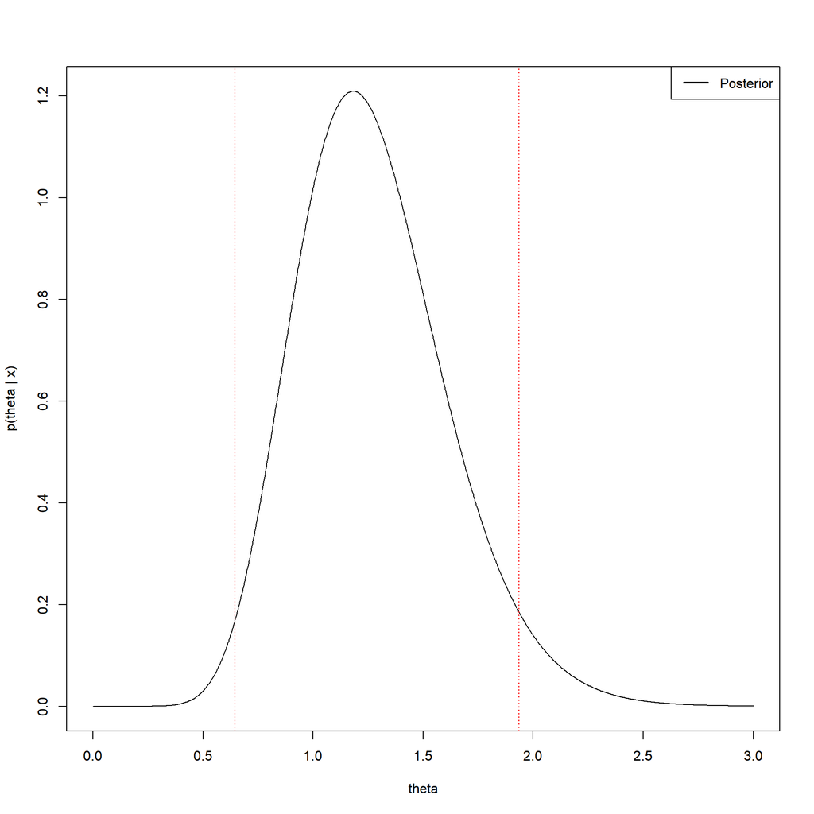

```r
a = 2; b=1
s = 12; n = 10
theta <- seq(0, 3, length.out = 1000)
plot(theta, dgamma(theta, a+s, b+n), type="l", xlab="theta",ylab="p(theta | x)")
legend("topright","Posterior",lty=1,lwd=2)

HPDsample <- function(theta,level=0.95){
  N=length(theta)
  theta.sort=sort(theta)
  M=ceiling(N*level)
  nCI=N-M
  CI.width=rep(0,nCI)
  for(i in 1:nCI) CI.width[i]=theta.sort[i+M]-theta.sort[i]
  index=which.min(CI.width)
  HPD=c(theta.sort[index], theta.sort[index+M])
  return(HPD)
}

posterior<- rgamma(10000, shape = a+s, rate = b+n)

HPD=HPDsample(posterior) #95% 최대사후구간
abline(v=HPD,lty=3, col = "red")
```

## 3-(3). 몬데칼로 기법을 사용하여 $log\theta$의 사후밀도함수와 95% 사후구간(HPD)을 그림으로 나타내라.

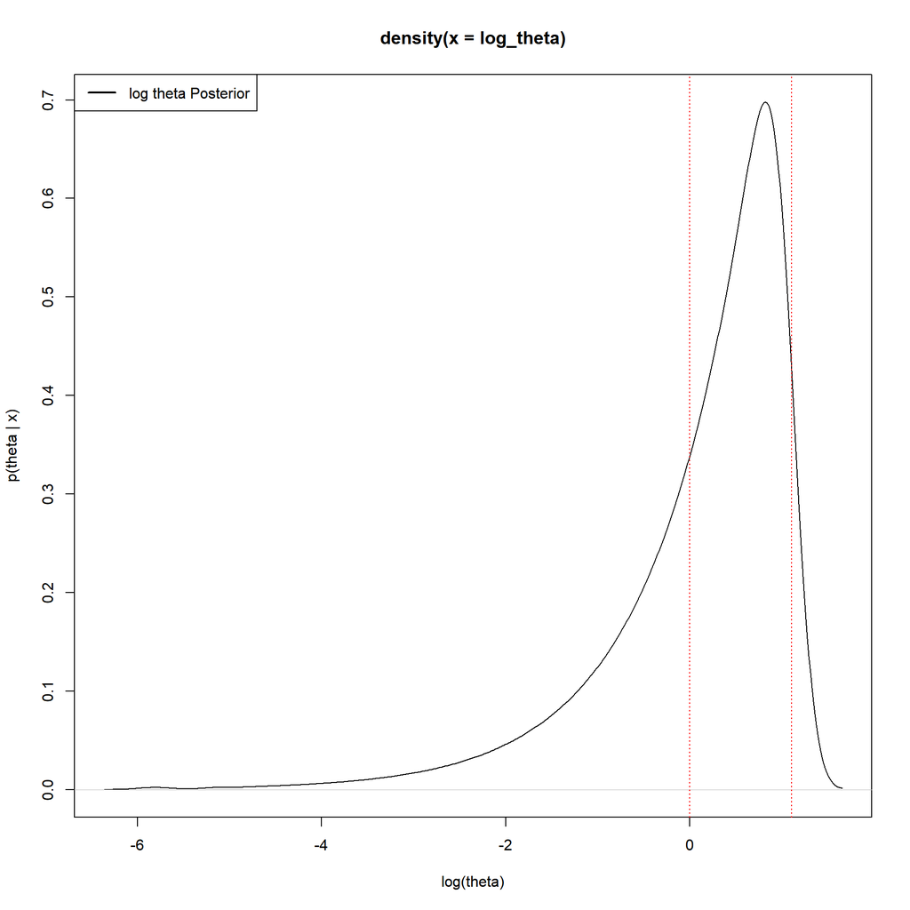

```r
# 로그 변환된 theta
log_theta <- log(theta)


plot(density(log_theta), type="l", xlab="log(theta)",ylab="p(theta | x)")
legend("topleft","log theta Posterior",lty=1,lwd=2)
posterior_1 <- dgamma(log_theta, a+s, b+n)

HPD=HPDsample(posterior_1) #95% 최대사후구간
abline(v=HPD,lty=3, col = "red")
```